# Homework06

Jorge Ruiz Arocho

2018 M02 21

#### Distribution Leaf Area

```r
z <- read.table("Fake Data Herbivory.csv",header=TRUE,sep=",", stringsAsFactors=FALSE)
str(z)
```

```
## 'data.frame':    100 obs. of  3 variables:
##  $ ï..ID                : int  1 2 3 4 5 6 7 8 9 10 ...
##  $ Total.Leaf.Area..cm2.: num  18.5 18 19.2 18.7 17.5 ...
##  $ X                    : logi  NA NA NA NA NA NA ...
```

```r
summary(z)
```

```
##      ï..ID        Total.Leaf.Area..cm2.    X
##  Min.   :  1.00   Min.   :10.23         Mode:logical
##  1st Qu.: 25.75   1st Qu.:15.08         NA's:100
##  Median : 50.50   Median :17.54
##  Mean   : 50.50   Mean   :17.01
##  3rd Qu.: 75.25   3rd Qu.:18.78
##  Max.   :100.00   Max.   :23.22
```

```r
head(z) # Updloading my data and summarizing it
```

```
##   ï..ID Total.Leaf.Area..cm2.  X
## 1     1                 18.50 NA
## 2     2                 18.01 NA
## 3     3                 19.25 NA
## 4     4                 18.74 NA
## 5     5                 17.52 NA
## 6     6                 16.48 NA
```

```r
H <- as.data.frame(cbind(z$ï..ID, z$Total.Leaf.Area..cm2))
head(H)
```

```
##   V1    V2
## 1  1 18.50
## 2  2 18.01
## 3  3 19.25
## 4  4 18.74
## 5  5 17.52
## 6  6 16.48
```

```r
names(H) <- c("ID", "LA")
str(H)
```

```
## 'data.frame':    100 obs. of  2 variables:
##  $ ID: num  1 2 3 4 5 6 7 8 9 10 ...
##  $ LA: num  18.5 18 19.2 18.7 17.5 ...
```

```r
head(H)
```

```
##   ID    LA
## 1  1 18.50
## 2  2 18.01
## 3  3 19.25
## 4  4 18.74
## 5  5 17.52
## 6  6 16.48
```

```r
library(ggplot2) # for graphics
library(MASS) # for maximum likelihood estimation
```

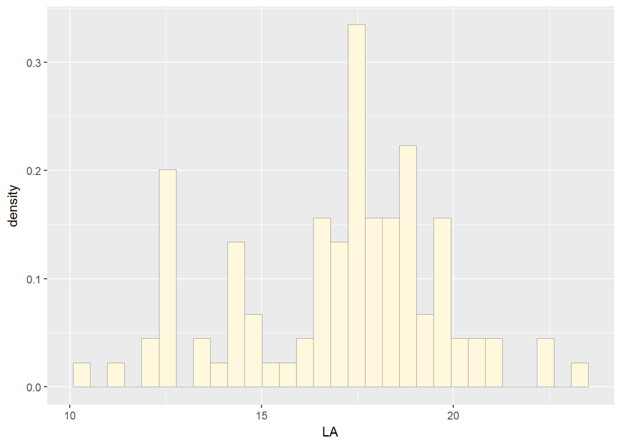

```r
p1 <- ggplot(data=H, aes(x=LA, y=..density..)) +
  geom_histogram(color="grey60",fill="cornsilk",size=0.2) #Here I am assigning my data to a ggplot density graph
print(p1)
```

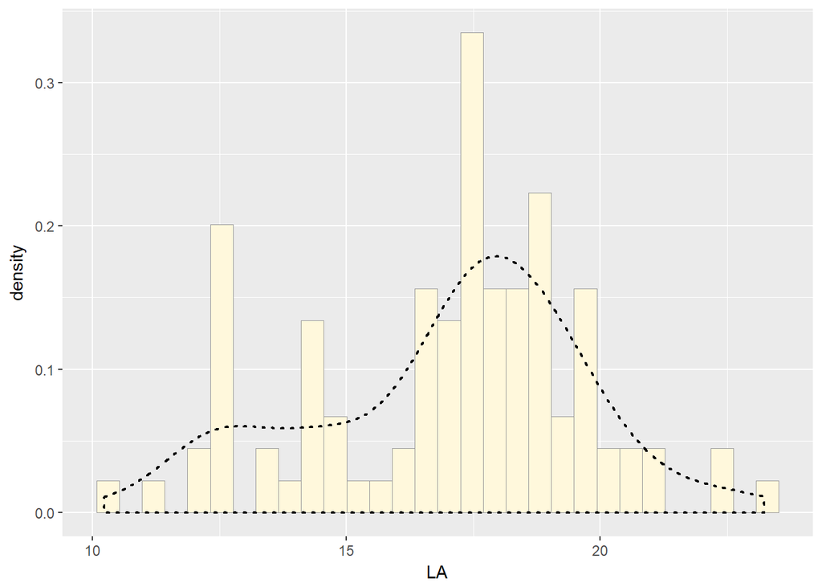

```r
p1 <-  p1 +  geom_density(linetype="dotted",size=0.75) #Here I am adding an empirical density curve to broadly observe the distribution of our data
print(p1)
```

```r
normPars <- fitdistr(H$LA,"normal") #Here I am fitting a normal distribution to my data and grabing the maximum likelihood estimators of the two parameters of a normal distribution.
print(normPars)
```

```
##       mean          sd
##   17.0086000    2.6732935
##  ( 0.2673293) ( 0.1890304)
```

```r
str(normPars)
```

```
## List of 5
##  $ estimate: Named num [1:2] 17.01 2.67
##   ..- attr(*, "names")= chr [1:2] "mean" "sd"
##  $ sd      : Named num [1:2] 0.267 0.189
##   ..- attr(*, "names")= chr [1:2] "mean" "sd"
##  $ vcov    : num [1:2, 1:2] 0.0715 0 0 0.0357
##   ..- attr(*, "dimnames")=List of 2
##   .. ..$ : chr [1:2] "mean" "sd"
##   .. ..$ : chr [1:2] "mean" "sd"
##  $ n       : int 100
##  $ loglik  : num -240
##  - attr(*, "class")= chr "fitdistr"
```

```r
normPars$estimate["mean"]
```

```
##    mean
## 17.0086
```

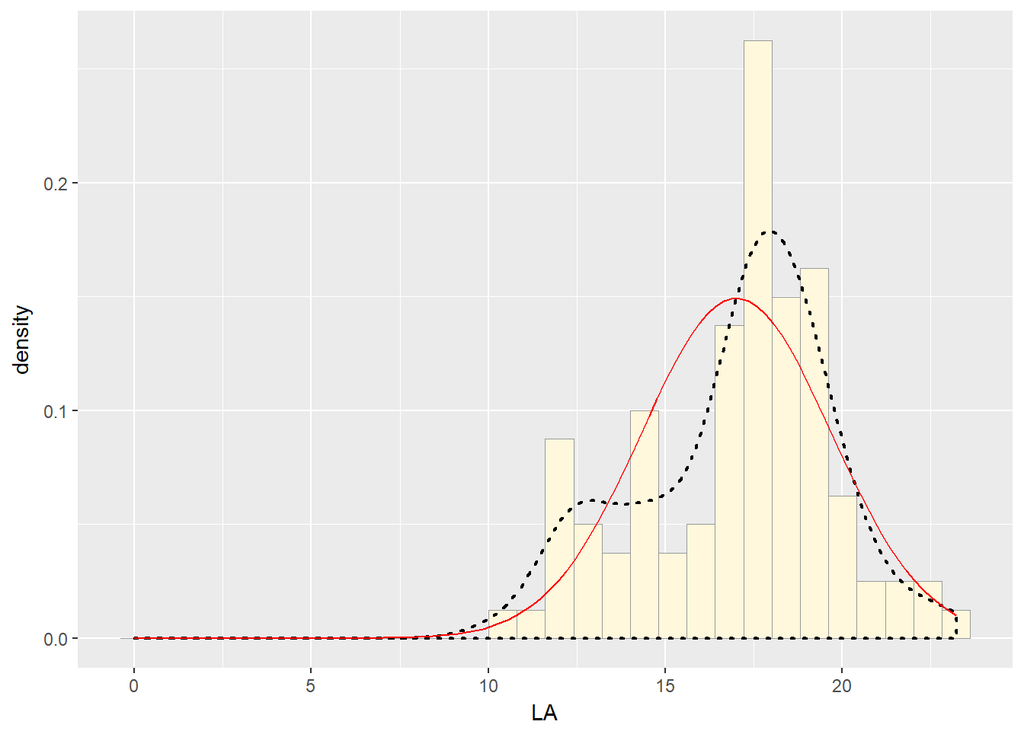

```r
meanML <- normPars$estimate["mean"]
sdML <- normPars$estimate["sd"]

xval <- seq(0,max(H$LA),len=length(H$LA))

stat <- stat_function(aes(x = xval, y = ..y..), fun = dnorm, colour="red", n =length(H$LA), args = list(mean = meanML, sd = sdML)) # Plotting a normal probability curve on my data.
p1 + stat
```

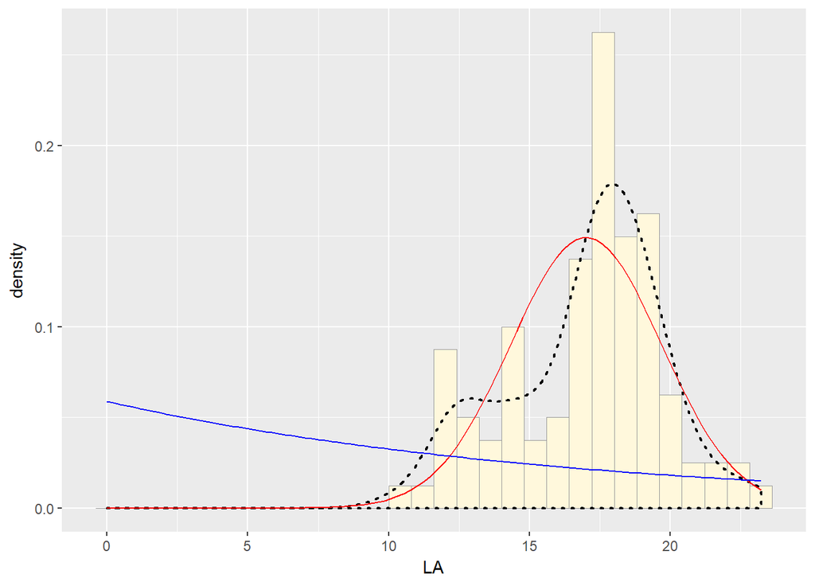

```r
expoPars <- fitdistr(H$LA,"exponential")
rateML <- expoPars$estimate["rate"]

stat2 <- stat_function(aes(x = xval, y = ..y..), fun = dexp, colour="blue", n = length(H$LA), args = list(rate=rateML)) # Plotting a exponential probability curve on my data.
p1 + stat + stat2
```

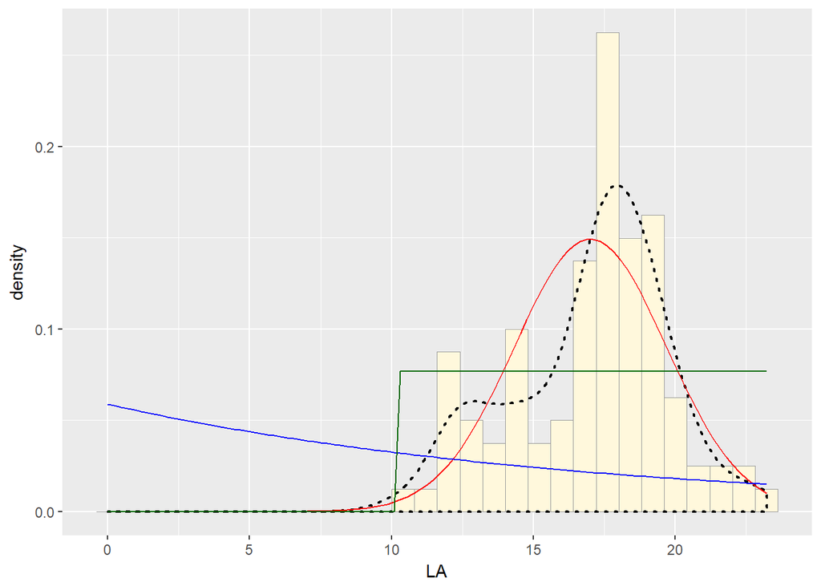

```r
stat3 <- stat_function(aes(x = xval, y = ..y..), fun = dunif, colour="darkgreen", n = length(H$LA), args = list(min=min(H$LA), max=max(H$LA))) # Plotting a uniform probability density plot on my data.
p1 + stat + stat2 + stat3
```

```r
gammaPars <- fitdistr(H$LA,"gamma")
```

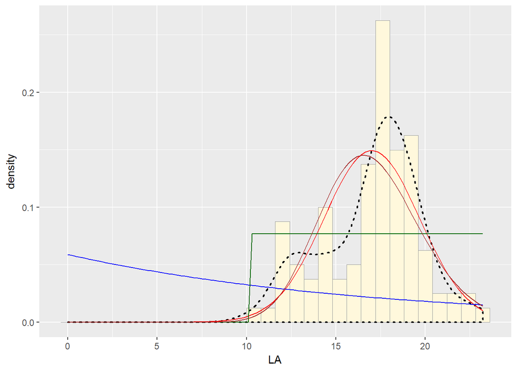

```r
shapeML <- gammaPars$estimate["shape"]
rateML <- gammaPars$estimate["rate"]

stat4 <- stat_function(aes(x = xval, y = ..y..), fun = dgamma, colour="brown", n = length(H$LA), args = list(shape=shapeML, rate=rateML)) # Plotting a gamma probability density plot on my data.
 p1 + stat + stat2 + stat3 + stat4
```

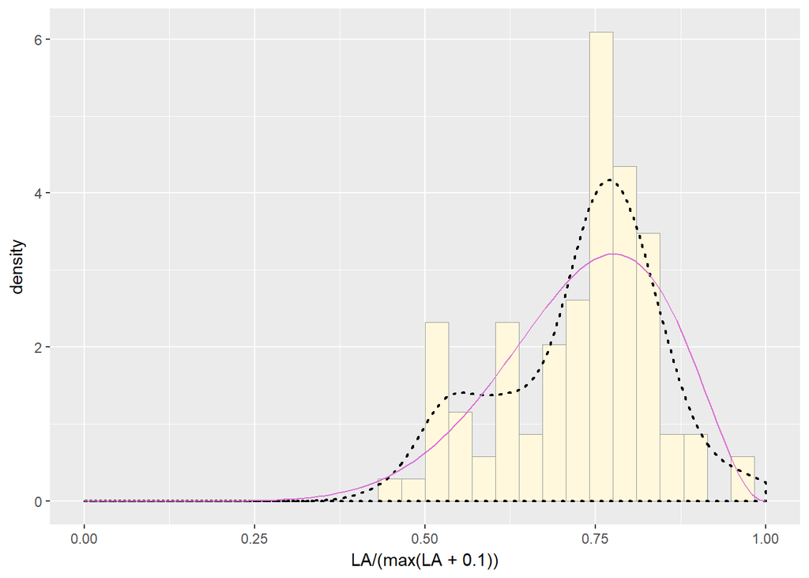

```r
pSpecial <- ggplot(data=H, aes(x=LA/(max(LA + 0.1)), y=..density..)) +
  geom_histogram(color="grey60",fill="cornsilk",size=0.2) +
  xlim(c(0,1)) +
  geom_density(size=0.75,linetype="dotted")

betaPars <- fitdistr(x=H$LA/max(H$LA + 0.1),start=list(shape1=1,shape2=2),"beta")
shape1ML <- betaPars$estimate["shape1"]
shape2ML <- betaPars$estimate["shape2"]

statSpecial <- stat_function(aes(x = xval, y = ..y..), fun = dbeta, colour="orchid", n = length(H$LA), args = list(shape1=shape1ML,shape2=shape2ML))
pSpecial + statSpecial # Plotting a beta probability density plot on my data, but on its own graph because the raw data must be rescaled so they are between 0 and 1, and then they can be compared to the beta.
```

#### Homework Question Number 5

1. Using the best-fitting distribution, go back to the code and get the maximum likelihood parameters. Use those to simulate a new data set, with the same length as your original vector, and plot that in a histogram and add the probability density curve. Right below that, generate a fresh histogram plot of the original data, and also include the probability density curve.
2. How do the two histogram profiles compare? Do you think the model is doing a good job of simulating realistic data that match your original measurements? Why or why not?

```r
normPars$loglik # The normal distribution appears to be the appropiate one (Highest number)
```

```
## [1] -240.225
```

```r
expoPars$loglik
```

```
## [1] -383.3719
```

```r
gammaPars$loglik
```

```
## [1] -243.1343
```

```r
z <- rnorm(n=100,mean=17.0061000, sd= 2.6720142) # Here I am simulating data based on the previous mean, sd, and length of my original data. I used rnorm because the normal distribution fits better on my original data.
z <- data.frame(1: 100,z)
names(z) <- list("ID","myVar")
z <- z[z$myVar>0,]
str(z)
```

```
## 'data.frame':    100 obs. of  2 variables:
##  $ ID   : int  1 2 3 4 5 6 7 8 9 10 ...
##  $ myVar: num  12 17.8 12.4 18.8 20.8 ...
```

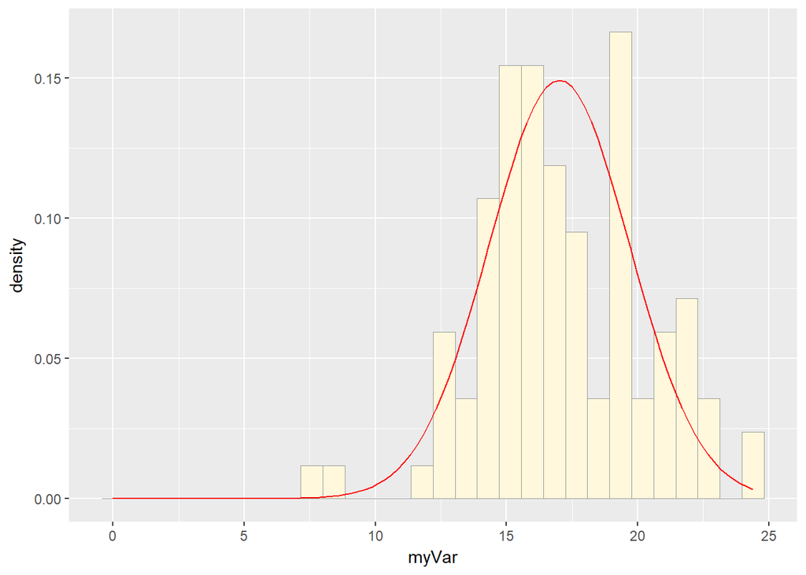

```r
p2 <- ggplot(data=z, aes(x=myVar, y=..density..)) +
  geom_histogram(color="grey60",fill="cornsilk",size=0.2)
p2 <-  p2 +  stat
print(p2)
```

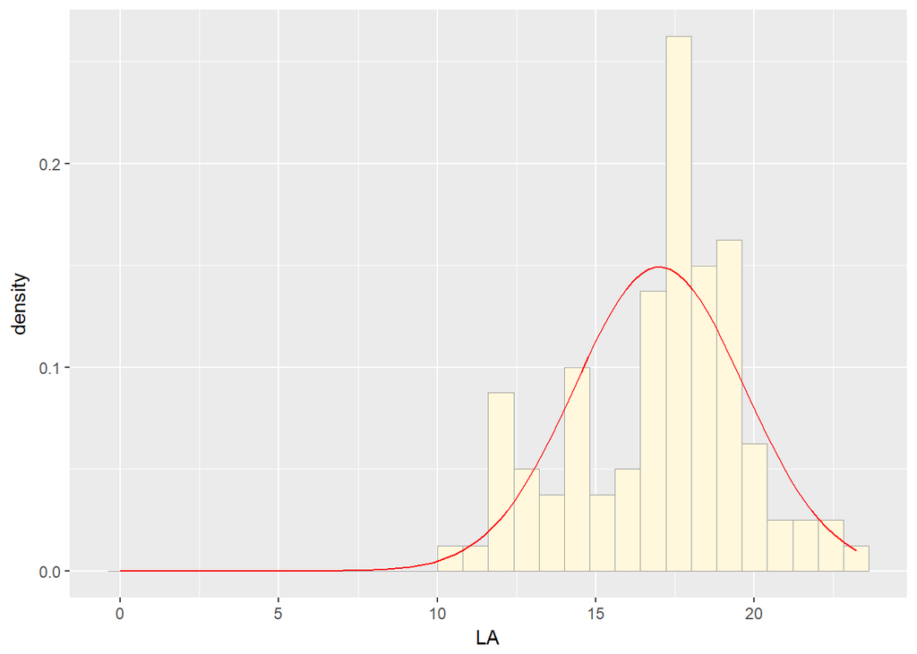

```r
p1 <- ggplot(data=H, aes(x=LA, y=..density..)) +
  geom_histogram(color="grey60",fill="cornsilk",size=0.2) #Here I am assigning my data to a ggplot density graph
p1 <-  p1 +  stat #Here I am adding an empirical density curve to broadly observe the distribution of our data
print(p1)
```

- The two histogram profiles are quite different, and based on our work the model is doing an average job simulating a realistic data that match our original measurente. But, I am conscience on the fact that we are using/and simulating data with few obervations (n=100). I assume that once we start workin with a significantly high number of observations these models should do a better job simulating real data.